# Bike Data Exploration

## Preliminary Wrangling

> This data set includes information about individual rides made in a bike-sharing system covering the greater San Francisco Bay area.

```python
# import all packages and set plots to be embedded inline
import numpy as np
import pandas as pd
import matplotlib.pyplot as plt
import seaborn as sb

%matplotlib inline
```

> Load in your dataset and describe its properties through the questions below. Try and motivate your exploration goals through this section.

```python
# load in the dataset into a pandas dataframe, print statistics
bike = pd.read_csv('2017-fordgobike-tripdata.csv')
```

```python
# high-level overview of data shape and composition
print(bike.shape)
print(bike.dtypes)
print(bike.head(10))
```

```
(519700, 15)
duration_sec                 int64
start_time                  object
end_time                    object
start_station_id             int64
start_station_name          object
start_station_latitude     float64
start_station_longitude    float64
end_station_id               int64
end_station_name            object
end_station_latitude       float64
end_station_longitude      float64
bike_id                      int64
user_type                   object
member_birth_year          float64
member_gender               object
dtype: object
   duration_sec                start_time                  end_time  \
0         80110  2017-12-31 16:57:39.6540  2018-01-01 15:12:50.2450
1         78800  2017-12-31 15:56:34.8420  2018-01-01 13:49:55.6170
2         45768  2017-12-31 22:45:48.4110  2018-01-01 11:28:36.8830
3         62172  2017-12-31 17:31:10.6360  2018-01-01 10:47:23.5310
4         43603  2017-12-31 14:23:14.0010  2018-01-01 02:29:57.5710
5          9226  2017-12-31 22:51:00.9180  2018-01-01 01:24:47.1660
6          4507  2017-12-31 23:49:28.4220  2018-01-01 01:04:35.6190
7          4334  2017-12-31 23:46:37.1960  2018-01-01 00:58:51.2110
8          4150  2017-12-31 23:37:07.5480  2018-01-01 00:46:18.3080
9          4238  2017-12-31 23:35:38.1450  2018-01-01 00:46:17.0530

   start_station_id                                 start_station_name  \
0                74                              Laguna St at Hayes St
1               284  Yerba Buena Center for the Arts (Howard St at ...
2               245                             Downtown Berkeley BART
3                60                               8th St at Ringold St
4               239                      Bancroft Way at Telegraph Ave
5                30     San Francisco Caltrain (Townsend St at 4th St)
6               259                            Addison St at Fourth St
7               284  Yerba Buena Center for the Arts (Howard St at ...
8                20    Mechanics Monument Plaza (Market St at Bush St)
9                20    Mechanics Monument Plaza (Market St at Bush St)
```

[output cut: 21 more lines]

```
7  Yerba Buena Center for the Arts (Howard St at ...             37.784872
8    Mechanics Monument Plaza (Market St at Bush St)             37.791300
9    Mechanics Monument Plaza (Market St at Bush St)             37.791300

   end_station_longitude  bike_id   user_type  member_birth_year member_gender
0            -122.415929       96    Customer             1987.0          Male
1            -122.426614       88    Customer             1965.0        Female
2            -122.267764     1094    Customer                NaN           NaN
3            -122.408445     2831    Customer                NaN           NaN
4            -122.265896     3167  Subscriber             1997.0        Female
5            -122.395282     1487    Customer                NaN           NaN
6            -122.299371     3539    Customer             1991.0        Female
7            -122.400876     1503    Customer                NaN           NaN
8            -122.399051     3125    Customer                NaN           NaN
9            -122.399051     2543    Customer                NaN           NaN
```

```python
# descriptive statistics for numeric variables
print(bike.describe())
```

```
        duration_sec  start_station_id  start_station_latitude  \
count  519700.000000     519700.000000           519700.000000
mean     1099.009521         95.034245               37.771653
std      3444.146451         86.083078                0.086305
min        61.000000          3.000000               37.317298
25%       382.000000         24.000000               37.773492
50%       596.000000         67.000000               37.783521
75%       938.000000        139.000000               37.795392
max     86369.000000        340.000000               37.880222

       start_station_longitude  end_station_id  end_station_latitude  \
count            519700.000000   519700.000000         519700.000000
mean               -122.363927       92.184041             37.771844
std                   0.105573       84.969491              0.086224
min                -122.444293        3.000000             37.317298
25%                -122.411726       23.000000             37.774520
50%                -122.398870       66.000000             37.783830
75%                -122.391034      134.000000             37.795392
max                -121.874119      340.000000             37.880222

       end_station_longitude        bike_id  member_birth_year
count          519700.000000  519700.000000      453159.000000
mean             -122.363236    1672.533079        1980.404787
std                 0.105122     971.356959          10.513488
min              -122.444293      10.000000        1886.000000
25%              -122.410345     787.000000        1974.000000
50%              -122.398525    1728.500000        1983.000000
75%              -122.391034    2520.000000        1988.000000
max              -121.874119    3733.000000        1999.000000
```

### What is the structure of your dataset?

> The dataset have 15 columns about bike rental information and 519700 rows about each rental.

### What is/are the main feature(s) of interest in your dataset?

> The main interest of the dataset is to identify the largest customer segment that we should target in marketing the Bike transit system.

### What features in the dataset do you think will help support your investigation into your feature(s) of interest?

> The columns that we will be using the most will be: user type, member birth year, member gender, duration sec, start time, end time.

## Univariate Exploration

> We will start investigate the main viarbles of the dataset

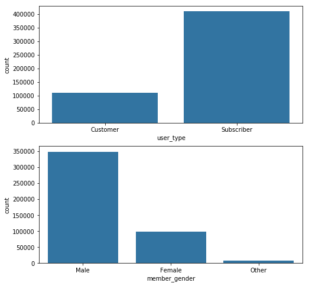

```python
fig, ax = plt.subplots(nrows=2, figsize = [8,8])

default_color = sb.color_palette()[0]
sb.countplot(data = bike, x = 'user_type', color = default_color, ax = ax[0])
sb.countplot(data = bike, x = 'member_gender', color = default_color, ax = ax[1])

plt.show()
```

We can notice that more subscribers use the bike service than the general public. Also, we notice that more Male use the bikes than Female.

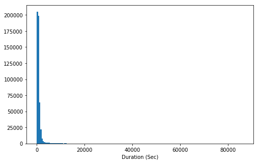

```python
# start with a standard-scaled plot of the duration seconds
binsize = 500
bins = np.arange(0, bike['duration_sec'].max()+binsize, binsize)

plt.figure(figsize=[8, 5])
plt.hist(data = bike, x = 'duration_sec', bins = bins)
plt.xlabel('Duration (Sec)')
plt.show()
```

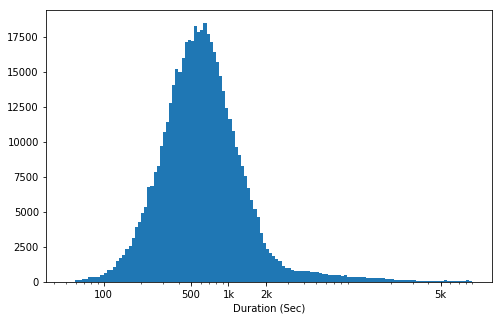

```python
# there's a long tail in the distribution, so let's put it on a log scale instead
log_binsize = 0.025
bins = 10 ** np.arange(1.7, np.log10(bike['duration_sec'].max())+log_binsize, log_binsize)

plt.figure(figsize=[8, 5])
plt.hist(data = bike, x = 'duration_sec', bins = bins)
plt.xscale('log')
plt.xticks([100, 500, 1e3, 2e3, 5e4], [100, 500, '1k', '2k', '5k'])
plt.xlabel('Duration (Sec)')
plt.show()
```

```python
# convert member birth year to int
bike.member_birth_year = pd.to_datetime(bike.member_birth_year)
bike.member_birth_year = bike.member_birth_year.astype(int,copy=False)
bike = bike[bike['member_birth_year'].notnull()]
```

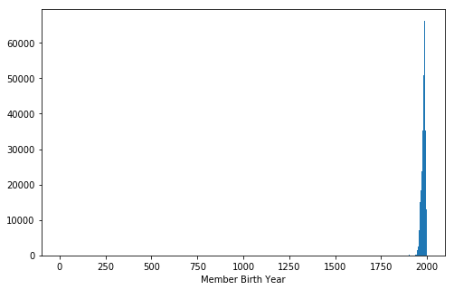

```python
bins = np.arange(0, bike['member_birth_year'].max(), 3)

plt.figure(figsize=[8, 5])
plt.hist(data = bike, x = 'member_birth_year', bins = bins)
plt.xlabel('Member Birth Year')
plt.show()
```

```python
bike['member_age'] = 2017 - bike.member_birth_year
```

```python
bike.member_age.value_counts()
```

```
-9223372036854773791    66541
 32                     24342
 29                     23610
 30                     22493
 33                     21061
 35                     21005
 31                     20134
 34                     19270
 28                     19202
 27                     16832
 26                     16009
 36                     15132
 37                     14817
 24                     13394
 38                     12691
```

[output cut: 47 more lines]

```python
bike.drop(bike[bike.member_age < 0].index, inplace = True)
```

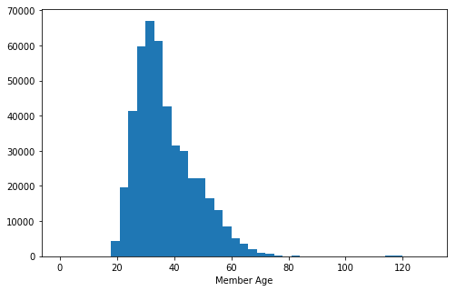

```python
bins = np.arange(0, bike['member_age'].max(), 3)

plt.figure(figsize=[8, 5])
plt.hist(data = bike, x = 'member_age', bins = bins)
plt.xlabel('Member Age')
plt.show()
```

> We can see from the previous plots that most of the users are Subscribers, Male and of age between 25 and 40.

### Of the features you investigated, were there any unusual distributions? Did you perform any operations on the data to tidy, adjust, or change the form of the data? If so, why did you do this?

> We converted member birth year into integr to calculate the age of each member in order for us to plot the age distribution of the users age.

## Bivariate Exploration

> In this section, we investigate the relationships between pairs of variables.

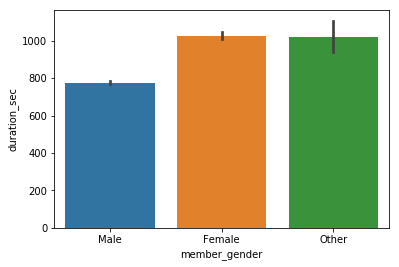

```python
sb.barplot(data = bike, x = 'member_gender', y = 'duration_sec')
```

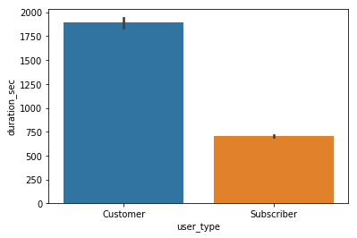

```python
sb.barplot(data = bike, x = 'user_type', y = 'duration_sec')
```

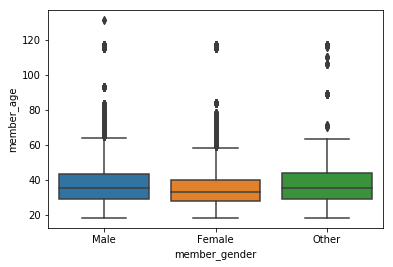

```python
sb.boxplot(x=bike["member_gender"], y=bike["member_age"] )
```

### Talk about some of the relationships you observed in this part of the investigation. How did the feature(s) of interest vary with other features in the dataset?

> We can notice that Female users tend to use the bike at longer duration than Male users. Also, customer use the bike service for a longer duration than subscribers of the bike service which might be becuase that most of the customers who are not subscribers are actually tourist who use the bike to enjoy thier time in San Francisco. Finally, Male users tend to be older and have an older median than the Female users.

### Did you observe any interesting relationships between the other features (not the main feature(s) of interest)?

> Many users did register their information wrongly or left it empty particularly in the date of birth info which created a huge distribution age birth year. We delt with that by removing all non values entries.

## Multivariate Exploration

> > In this section, we investigate the relationships between multivariate variables.

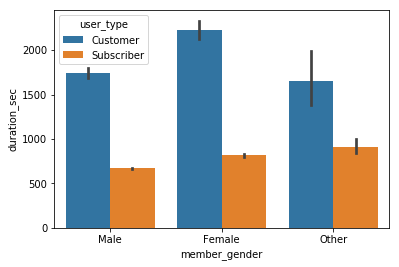

```python
sb.barplot(data = bike, x = 'member_gender', y = 'duration_sec', hue = 'user_type')
```

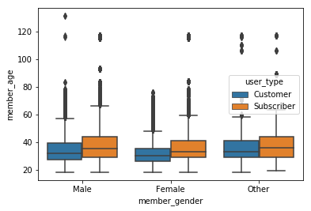

```python
sb.boxplot(x=bike["member_gender"], y=bike["member_age"], hue = bike['user_type'])
```

### Talk about some of the relationships you observed in this part of the investigation. Were there features that strengthened each other in terms of looking at your feature(s) of interest?

> Females use the bike service for a longer period whether they are customers of subscribers. However, Subscribers are older in general in both genders with larger age gap in users.

### Were there any interesting or surprising interactions between features?

> At first we thought that Male users are dominante and should be our target users; however, after further analysis we can see that the Female segment is important and more avid users even at older age.

> At the end of your report, make sure that you export the notebook as an html file from the `File > Download as... > HTML` menu. Make sure you keep track of where the exported file goes, so you can put it in the same folder as this notebook for project submission. Also, make sure you remove all of the quote-formatted guide notes like this one before you finish your report!